# 6.1. Data Visualisation

Module M-227-04: Programming for Data Analytics

Instructor: Nadežda Zeņina

Course author: Dmitry Pavlyuk

## Today

1. **Principles** of data visualisation and the three Python layers: pandas → matplotlib → seaborn
2. **Plots from pandas** - histogram, density, box, scatter, bar, pie, line, area: which one for which question
3. **matplotlib fundamentals** - the anatomy of a figure, several plots in one figure (`subplots`), titles, labels, honest scales
4. **seaborn fundamentals** - themes, `hue=`, histogram + density, violin plots, heatmaps, regression lines
5. **Mini-project** - two charts and their conclusions, the format of the project report

No lab for this block - the **independent project** starts now; today's figures are the model for its visualisation part.

## Data Visualisation

Data visualization involves **making sense of data** by presenting it in an easily understandable format.

Core principles:

1. Focus on your audience
2. Use standard tools/plots where it is possible
3. Follow general rules: figure and axis labels, layouts, etc.
4. Keep it simple (but informative)
5. Storify your data

All these and other aspects of data visualisation are covered by the specialisation course **"Data Visualisation and Business Intelligence"**.

In this topic we focus just on **technical aspects** of data visualisation in Python.

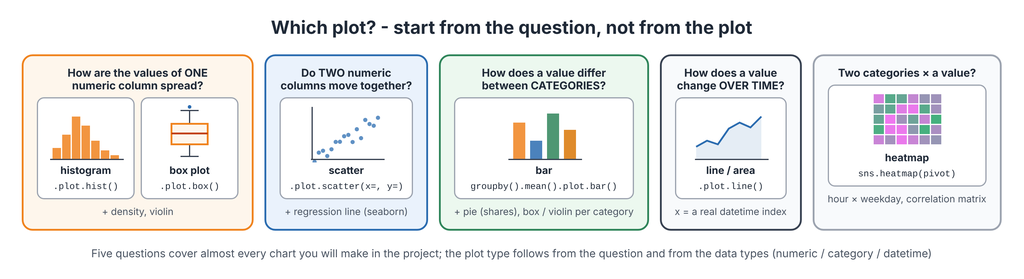

### Data Visualisation - matplotlib

**Matplotlib** (first released in 2003) is the most popular library for data visualisation in Python.

It's extremely flexible, so you have almost full control on your plots.

pandas .plot for a quick look, matplotlib for full control, seaborn for statistical plots - all three draw with matplotlib

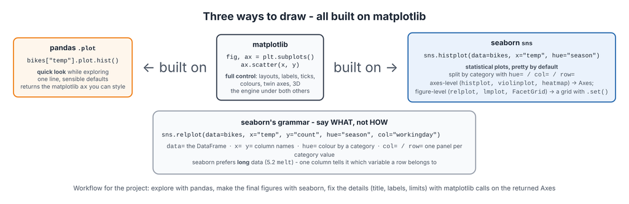

Three layers, draw with matplotlib underneath.

- pandas (one line, good enough while exploring)
- matplotlib (when the figure goes into a report and every label matters)
- seaborn (statistical plots and nicer defaults).

```python
!pip install matplotlib
```

```python
import matplotlib.pyplot as plt
%matplotlib inline
```

Note tha "magic" command that starts with %

`%matplotlib inline` tells Jupyter / Colab to show the plots **inside the notebook**, under the cell (it is the default in Colab, so you rarely need it, but it does no harm). `plt` is the conventional short name for `matplotlib.pyplot`, like `np` and `pd`.

## Data set - Bikes Sharing Demand

This presentation uses the popular Bikes Sharing Demand data set - please review the data set description in the presentation on Pandas.

```python
import pandas as pd
import numpy as np
```

### Loading data set

The data set is split into two parts (training and testing data); we just combine them for presentation:

```python
bikes = pd.read_csv("../content/bikes.csv")
bikes2 = pd.read_csv("../content/bikes_test.csv")
bikes = pd.concat([bikes,bikes2])
bikes.head()
```

|  | datetime | season | holiday | workingday | weather | temp | atemp | humidity | windspeed | casual | registered | count |
| --- | --- | --- | --- | --- | --- | --- | --- | --- | --- | --- | --- | --- |
| 0 | 01/01/2011 00:00 | spring | 0 | 0 | 1 | 9.84 | 14.395 | 81 | 0.0 | 3.0 | 13.0 | 16.0 |
| 1 | 01/01/2011 01:00 | spring | 0 | 0 | 1 | 9.02 | 13.635 | 80 | 0.0 | 8.0 | 32.0 | 40.0 |
| 2 | 01/01/2011 02:00 | spring | 0 | 0 | 1 | 9.02 | 13.635 | 80 | 0.0 | 5.0 | 27.0 | 32.0 |
| 3 | 01/01/2011 03:00 | spring | 0 | 0 | 1 | 9.84 | 14.395 | 75 | 0.0 | 3.0 | 10.0 | 13.0 |
| 4 | 01/01/2011 04:00 | spring | 0 | 0 | 1 | 9.84 | 14.395 | 75 | 0.0 | 0.0 | 1.0 | 1.0 |

### Data quality: what do we actually have?

`pd.concat` (5.2) stacked the two tables: 10 886 + 6 493 = 17 379 hourly rows, covering **every day** of 2011-2012 - but the rental columns are empty for the 6 493 test rows:

```python
print(bikes.shape)
bikes.isna().sum()
```

```
(17379, 12)
```

|  | 0 |
| --- | --- |
| datetime | 0 |
| season | 0 |
| holiday | 0 |
| workingday | 0 |
| weather | 0 |
| temp | 0 |
| atemp | 0 |
| humidity | 0 |
| windspeed | 0 |
| casual | 6493 |
| registered | 6493 |
| count | 6493 |

**dtype:** int64

This matters for every chart today: a plot of **temperature** uses all 17 379 hours, a plot of **rentals** uses only the 10 886 hours where `count` is known - pandas and seaborn drop the `NaN` rows silently and the chart does not tell you. To keep that visible we give the complete rows a name of their own and use it whenever rentals are involved (`bikes` itself stays as Dmitry built it):

```python
bikes_known = bikes.dropna(subset=["count"])        # the 10 886 hours with known rentals
print(len(bikes), "hours in total,", len(bikes_known), "with rental counts")
```

```
17379 hours in total, 10886 with rental counts
```

### Defining data types

A proper definition of column types is necessary for correct data visualisation:

```python
bikes["datetime"] = pd.to_datetime(bikes["datetime"], format='%d/%m/%Y %H:%M')
bikes["season"] = bikes["season"].astype('category')
bikes["weather"] = bikes["weather"].astype('category')
bikes["holiday"] = bikes["holiday"].astype('category')
bikes["workingday"] = bikes["workingday"].astype('category')
bikes["humidity"] = bikes["humidity"].astype(float)
bikes.dtypes
```

|  | 0 |
| --- | --- |
| datetime | datetime64[ns] |
| season | category |
| holiday | category |
| workingday | category |
| weather | category |
| temp | float64 |
| atemp | float64 |
| humidity | float64 |
| windspeed | float64 |
| casual | float64 |
| registered | float64 |
| count | float64 |

**dtype:** object

```python
bikes_known = bikes.dropna(subset=["count"])        # re-made from the typed table, so the dtypes match
bikes_known.dtypes["datetime"], bikes_known.dtypes["season"]
```

```
(dtype('<M8[ns]'),
 CategoricalDtype(categories=['fall', 'spring', 'summer', 'winter'], ordered=False, categories_dtype=object))
```

## matplotlib from Pandas

**Pandas** seemless integrates several most frequently used **matplotlib** plots:

- histograms
- bar plots
- scatters
- boxplots

## Histogram from Pandas

Histograms are used for visualising distribution of **continuous quantitative variables** (like *temperature*) or **discrete quantitative variables** with many unique values (like *count*)

- Single histogram

A histogram counts the values in bins; a density plot smooths every value with a kernel into a curve

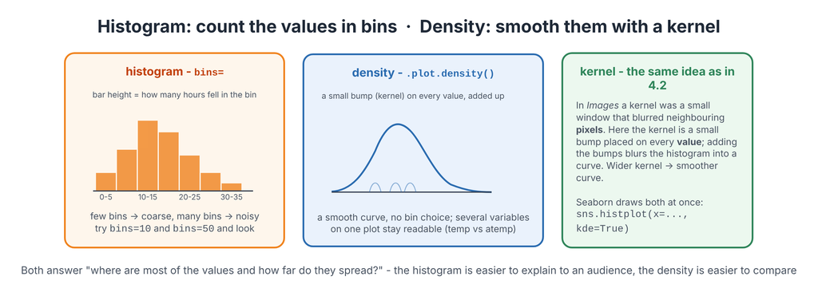

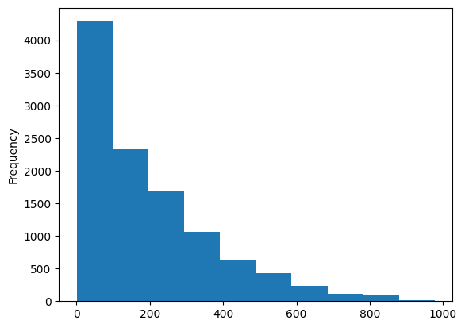

```python
bikes["count"].plot.hist()
```

### Histogram from Pandas

- Several histograms - separate axis

```
array([[<Axes: title={'center': 'temp'}>,
        <Axes: title={'center': 'atemp'}>]], dtype=object)
```

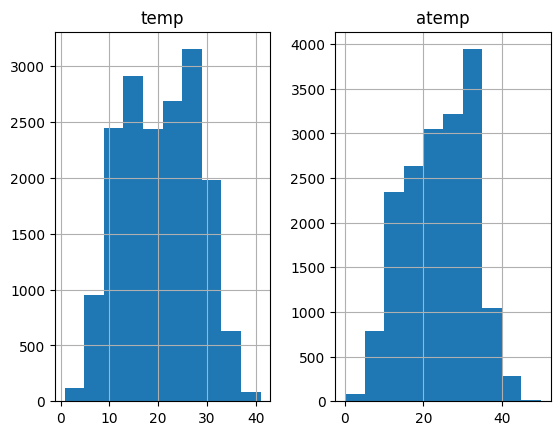

```python
bikes[["temp", "atemp"]].hist()
```

### Histogram from Pandas

- Several histograms - shared axis

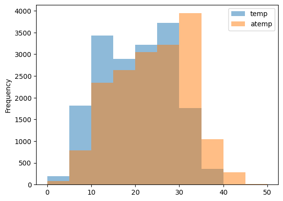

```python
bikes[["temp", "atemp"]].plot.hist(bins=10, alpha=0.5)
```

Two forms: `df.hist()` → one panel **per column**; `df.plot.hist()` → all columns **in one panel**, where `alpha=0.5` (transparency) lets us see both. `bins=10` sets the number of bars - try 5 and 50 and see how the picture changes. (Temperature is known for all 17 379 hours, so these use the whole table.)

## Density plots from Pandas

Density plots provide more detailed information on distribution of quantitative variables by applying **kernels**.

Kernels are applied for every unique in the data set and provide weights for smoothing with neighbour values.

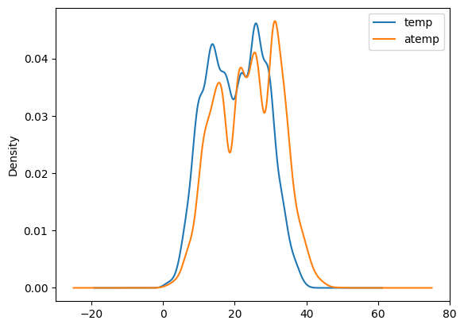

```python
bikes[["temp", "atemp"]].plot.density();
```

Kernel density plots are much easier to read then several histograms on the same plot

- histogram shows actual counts of values in bins;
- density plot is a smoothed estimate of the same distribution - a small bump is placed on every value and the bumps are added up.
- The smooth curve is convenient for comparing several columns (`atemp` sits a few degrees to the right of `temp`), but smoothing can invent shape where there is none - a curve that continues below 0 °C, or a smooth hill over values that are really discrete. Use the density for comparing shapes, the histogram when the actual numbers matter. The vertical axis is a *density*: the area under each curve is 1.

## Box plots from Pandas

Box (box-and-whiskers) plots are used to represent most important desriptive statistics of a variable:

- Median - line in the middle)
- Quartiles (25% and 75%) - the box
- "Normal" deviation (different metrics) - the "whiskers"
- Outliers - circles ouside the whiskers

A box plot is describe() drawn: median, quartiles, whiskers, outliers

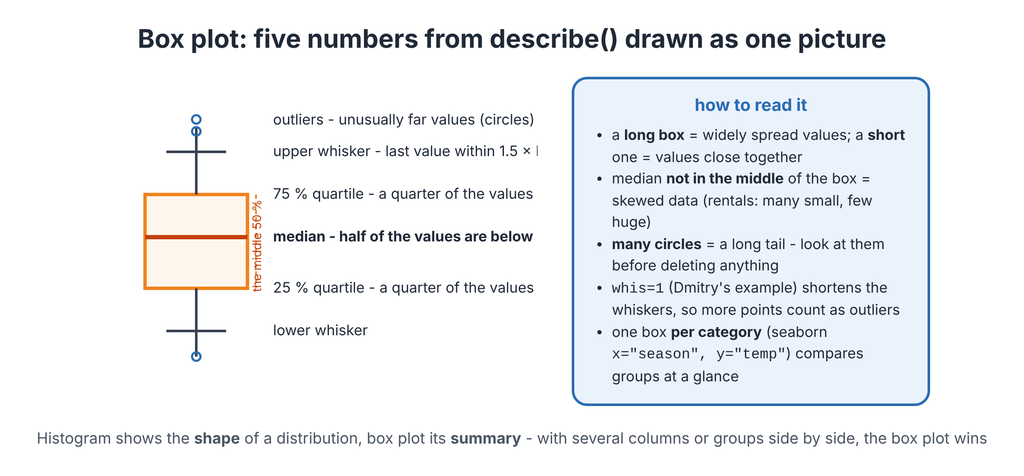

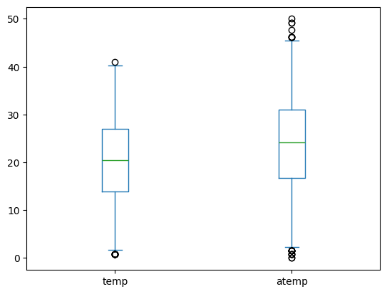

```python
bikes[["temp", "atemp"]].plot.box(whis=1);
```

- One box per column, same scale - the quickest way to compare several numeric columns.
- `whis=1` sets the whisker length to 1 × the box height (default 1.5), so more points are shown as outlier circles;

## Scatter plots from Pandas

Scatter (XY) plots display all observations of two variables as points on the two-dimensional Cartesian plane and used to represent a relationship between variables:

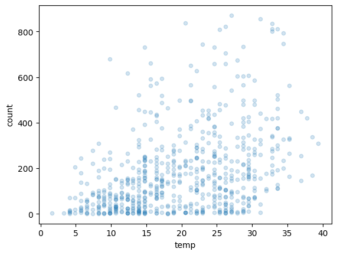

```python
bikes.sample(1000).plot.scatter(x="temp", y="count",alpha=0.2)
```

Every point is one hour (of the 10 886 with known rentals): x its temperature, y its rentals.

The cloud rises to the right (the correlation of 0.39 from 5.1) and is widest in the middle - at 25 °C an hour can have 5 or 900 rentals, so temperature is only part of the story.

## Bar plots from Pandas

Bar plots represent categorical data with rectangular bars with heights that is proportional to the values which they represent.

```python
bikes.groupby("season").agg({'count':'median'})
```

| season | count |
| --- | --- |
| fall | 195.0 |
| spring | 78.0 |
| summer | 172.0 |
| winter | 161.0 |

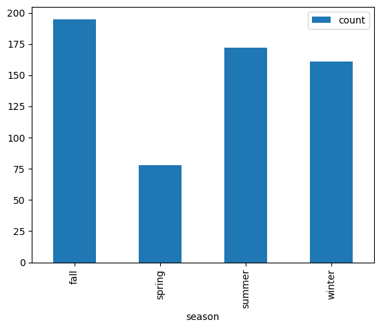

```python
bikes.groupby("season").agg({'count':'median'}).plot.bar()
```

For bar chart: groupby → one number per category → .plot.

## Pie charts from Pandas

Pie charts are also used for representing categorical data, but are based on circle slices and usually better for representing relative values.

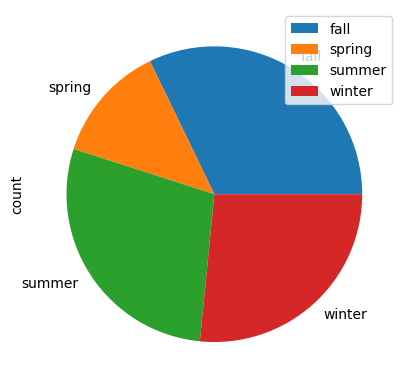

```python
bikes.groupby("season").agg({'count':'median'}).plot.pie(y="count")
```

**Counterexample - do not use.** A pie shows **shares of a whole**, and the four medians are not shares of anything: a median of 195 rentals in fall is not "32 % of the rentals". The slices look reasonable, which is exactly what makes this chart dangerous - the reader believes it. A *valid* pie of the same data answers the question *"which share of all rentals happened in each season?"* - the **totals**, which do add up to 100 %:

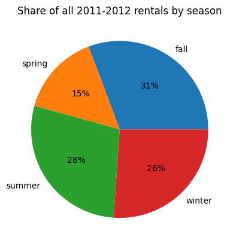

```python
totals = bikes_known.groupby("season", observed=True)["count"].sum()
ax = totals.plot.pie(autopct="%.0f%%", ylabel="")
ax.set_title("Share of all 2011-2012 rentals by season");
```

Even then, with more than 4-5 slices or slices of similar size a bar chart is easier to compare; pies are for "one big part vs. the rest".

## Line plots from Pandas

Line plots represent a series of values, ordered by the numeric scale

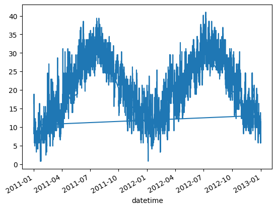

```python
bikes.set_index("datetime")['temp'].plot.line()
```

A line needs an **ordered** x-axis - time, or a numeric scale. `set_index("datetime")` puts the real dates on the x-axis (that is why we converted the type). Two yearly cycles are visible; the dense "hair" is the day-night temperature swing of 17 000 hourly points. Smoothing to weekly means (appendix, *Formatter*) makes the trend cleaner.

## Area plots from Pandas

Area plots are line plots with filled area underneath. Frequently used in a stacked form for representing dinamics of components (e.g., registered and casual bike rentals).

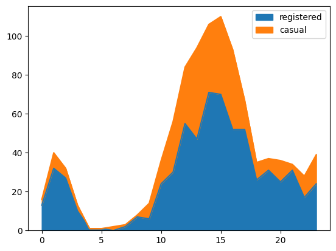

```python
first_day = min(bikes["datetime"].dt.date)
bikes.loc[bikes['datetime'].dt.date==first_day,["registered","casual"]].plot.area()
```

Reading the two lines: `first_day` is the earliest date in the data (1 January 2011); the mask keeps the 24 hours of that day; the area plot **stacks** `casual` on top of `registered`, so the upper edge is the total. On a holiday morning registered users dominate; casual riders appear in the afternoon. (The x-axis shows the row position 0-23 = the hour, because the index is still the default one.)

## matplotlib

Although Pandas plot functions are convenient, constructing figures by matplotlib from scratch gives you the full control over the results.

Frequently used feature that require direct usage of **matplotlib**:

- Advanced layouts
- Full control over presentation

### Anatomy of *matplotlib* figure

[figure not shown]

One Figure (the canvas) holds one or more Axes (plot areas); title, axis labels, ticks, legend and grid belong to the Axes

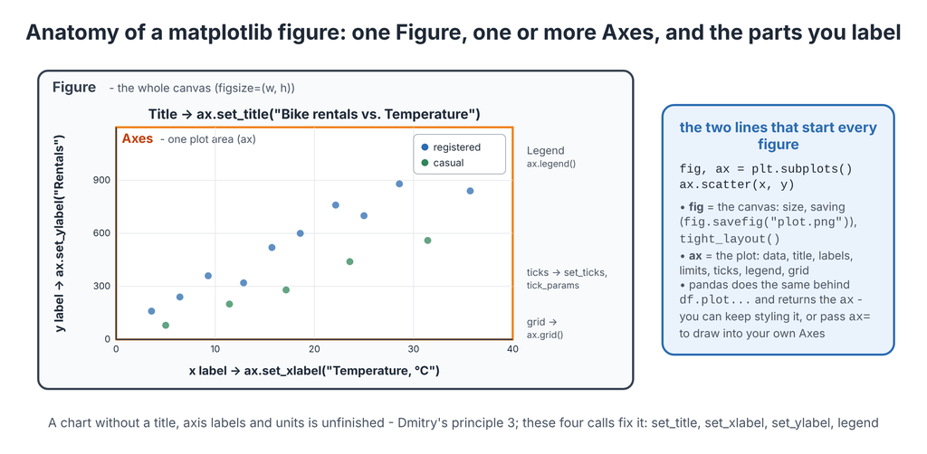

- **Figure** is the whole canvas (its size, saving to a file),
- **Axes** is one plot area with its own title, labels and ticks. A figure can hold several Axes - that is how we get several plots in one picture.
- `plt.subplots()` creates both and hands them back as `figure, axis`.

### Matplotlib figure: example

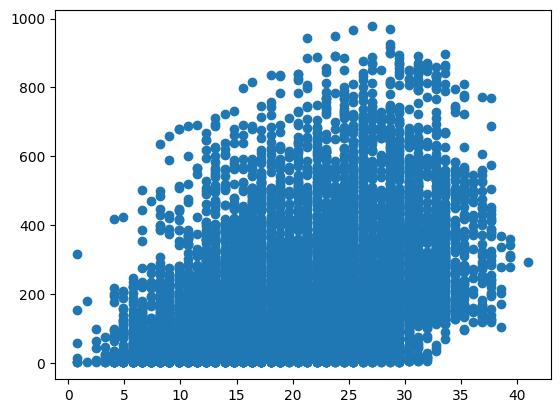

```python
figure, axis = plt.subplots()
axis.scatter(x=bikes['temp'], y=bikes['count'])
plt.show()
```

The same scatter as `bikes.plot.scatter(...)`, written in three explicit lines: create figure + axes, draw on the axes, show. From now on everything we want to change - a title, a label, a second plot - is a method call on `axis`.

### Advanced layout: subplots

plt.subplots(rows, cols) returns a grid of Axes; address them by index, flatten() turns the grid into a simple list

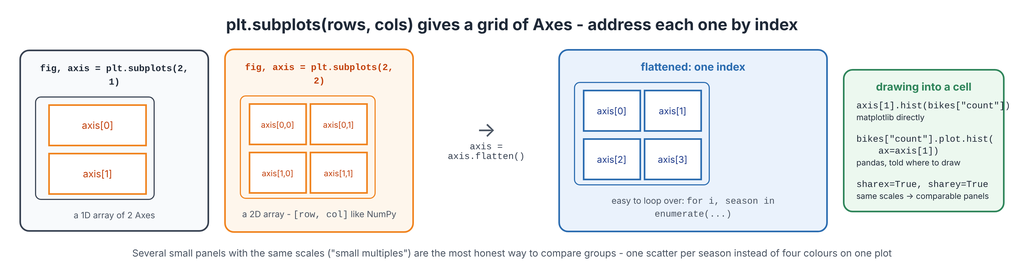

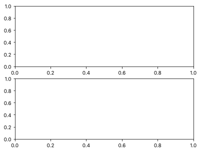

```python
figure, axis = plt.subplots(2, 1)
```

```python
print(axis)
```

```
[<Axes: > <Axes: >]
```

`subplots(2, 1)` - 2 rows, 1 column: an empty figure with two Axes, returned as a NumPy **array** (4.1!) - `axis[0]` is the top one, `axis[1]` the bottom one.

### Advanced layout: plotting on different axis

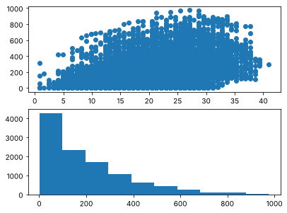

```python
figure, axis = plt.subplots(2, 1)
axis[0].scatter(x=bikes['temp'], y=bikes['count'])
axis[1].hist(bikes['count'])
plt.show()
```

### Advanced layout: using axis by Pandas

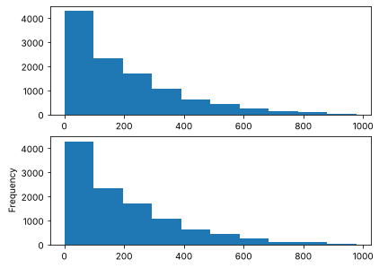

```python
figure, axis = plt.subplots(2, 1)
axis[0].hist(bikes['count'])
bikes['count'].plot.hist(ax=axis[1])
plt.show()
```

Two ways to draw into a cell of the grid: matplotlib directly (`axis[0].hist(...)`) or pandas with `ax=axis[1]` - "draw your plot *there*". Both give the same histogram; the pandas one adds the axis label for free. Mixing them is normal. (Both silently ignore the `NaN` rows of the test part - neither tells you that only 10 886 of the 17 379 hours are drawn. One more reason to plot rentals from `bikes_known`.)

### Advanced layout: grid

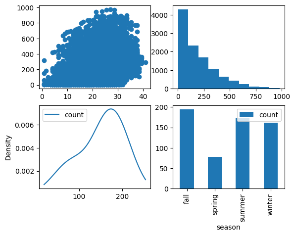

```python
figure, axis = plt.subplots(2, 2)
axis = axis.flatten()
axis[0].scatter(x=bikes['temp'], y=bikes['count'])
axis[1].hist(bikes['count'])
bikes.groupby("season").agg({'count':'median'}).plot.density(ax=axis[2])
bikes.groupby("season").agg({'count':'median'}).plot.bar(ax=axis[3])
plt.show()
```

A 2 × 2 grid is a 2D array of Axes; `axis.flatten()` (4.1) turns it into a flat list so we can count 0, 1, 2, 3 instead of `[0, 0]`, `[0, 1]` ... Four plots, one figure - a **layout** demonstration. Panel 2 (bottom left) is deliberately a bad chart: a density estimated from **four** medians says nothing about the data. The meaningful plot for that cell is a comparison of the rentals *per season* - and the labels need `tight_layout()`:

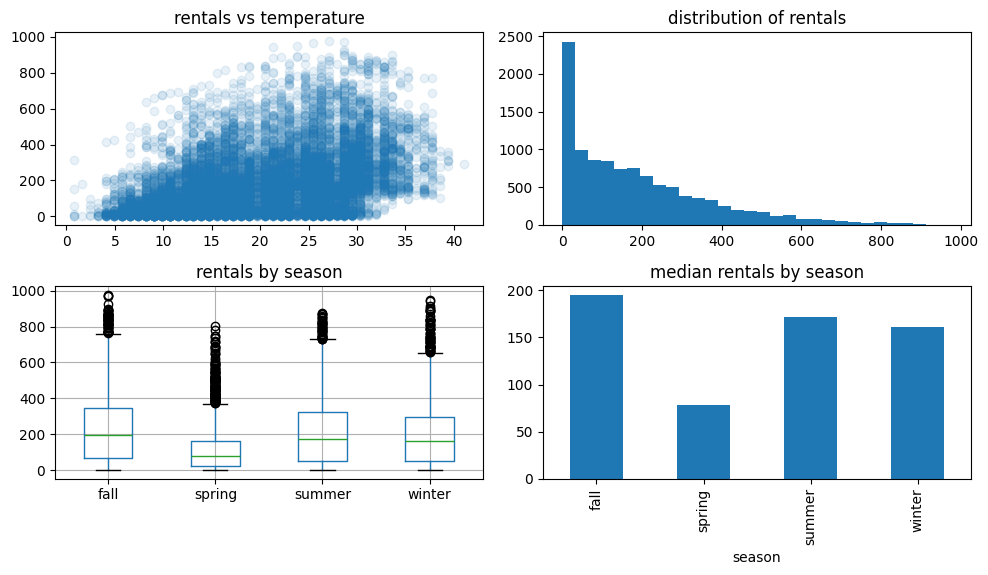

```python
figure, axis = plt.subplots(2, 2, figsize=(10, 6))
axis = axis.flatten()
axis[0].scatter(x=bikes_known['temp'], y=bikes_known['count'], alpha=0.1); axis[0].set_title("rentals vs temperature")
axis[1].hist(bikes_known['count'], bins=30);                               axis[1].set_title("distribution of rentals")
bikes_known.boxplot(column="count", by="season", ax=axis[2]);             axis[2].set_title("rentals by season"); axis[2].set_xlabel("")
medians.plot.bar(ax=axis[3]);                                              axis[3].set_title("median rentals by season")
figure.suptitle("")                                   # pandas' boxplot adds a figure title - remove it
figure.tight_layout(); plt.show()
```

### Advanced layout: grids

Problem: plot count/temperature scatters for different seasons

```python
bikes['season'].unique()
```

```
['spring', 'summer', 'fall', 'winter']
Categories (4, object): ['fall', 'spring', 'summer', 'winter']
```

**Accent**

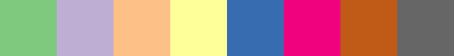

under

bad

over

```python
plt.cm.Accent
```

Two preparations: the list of seasons to loop over, and a **colormap** - a ready-made set of colours (`plt.cm.Accent` has 8); `plt.cm.Accent.colors[i]` picks the i-th one. Many colormaps exist (`viridis`, `coolwarm`, ...); for categories pick a *qualitative* one like `Accent` or `tab10`.

### Advanced layout: grids

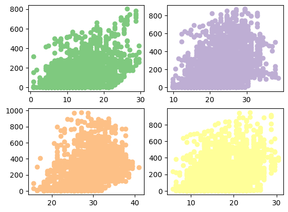

```python
figure, axis = plt.subplots(2, 2)
axis = axis.flatten()
i = 0
for season in bikes['season'].unique():
    axis[i].scatter(x=bikes.loc[bikes['season']==season,'temp'],
                    y=bikes.loc[bikes['season']==season,'count'],
                    color=plt.cm.Accent.colors[i])
    i+=1
plt.show()
```

A `for` loop (week 2) over the four seasons: filter the rows of one season with a mask (5.1), draw them on panel `i`, move to the next panel. This "one panel per group" pattern - **small multiples** - is the most honest way to compare groups, and the loop is the same for 4 or 40 groups.

### Advanced layout: shared axes

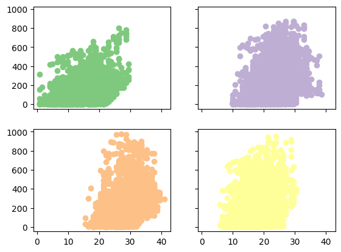

```python
figure, axis = plt.subplots(2, 2, sharex=True, sharey=True)
axis = axis.flatten()
i = 0
for season in bikes['season'].unique():
    axis[i].scatter(x=bikes.loc[bikes['season']==season,'temp'],
                    y=bikes.loc[bikes['season']==season,'count'],
                    color=plt.cm.Accent.colors[i])
    i+=1
plt.show()
```

Compare with the previous figure: there each panel had its **own** scale, so spring (0-30 °C) looked as wide as fall (15-40 °C). `sharex=True, sharey=True` gives all panels the same axes - now the shift of the clouds to the right from spring to fall is visible, and the inner tick labels disappear. Panels that are meant to be compared must share scales.

### Full control: adding titles and labels

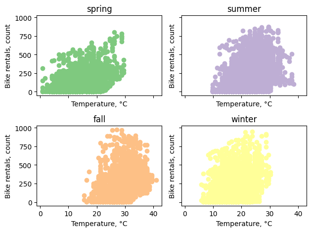

```python
deg = u'\N{DEGREE SIGN}'

figure, axis = plt.subplots(2, 2, sharex=True, sharey=True)
axis = axis.flatten()
i = 0
for season in bikes['season'].unique():
    axis[i].scatter(x=bikes.loc[bikes['season']==season,'temp'],
                    y=bikes.loc[bikes['season']==season,'count'],
                    color=plt.cm.Accent.colors[i])
    axis[i].set_title(season)
    axis[i].set_xlabel("Temperature, "+deg+"C")
    axis[i].set_ylabel("Bike rentals, count")
    i+=1
figure.tight_layout()
plt.show()
```

- very panel has a **title** (the season) and both axes have **names with units** (`deg` is the ° character).
- `figure.tight_layout()` spreads the panels so nothing overlaps.
- These three calls - `set_title`, `set_xlabel`, `set_ylabel` - are the minimum for any figure

### Full control: plot attributes

```python
def make_plot():
    figure, axis = plt.subplots(figsize=(12, 5))
    for season in bikes['season'].unique():
        axis.scatter(x=bikes.loc[bikes['season']==season,'temp'],
                     y=bikes.loc[bikes['season']==season,'count'],
                     label=season, cmap=plt.cm.Accent)
    axis.set_title("Bike rentals vs. Temperature") #Title
    axis.set_xlabel("Temperature, "+deg+"C") # X axis' label
    axis.set_ylabel("Bike rentals, count") # Y axis' label
    axis.set_ylim([0,1200]) # Y axis' limits
    axis.set_xlim([0,45]) # X axis' limits
    startx, endx = axis.get_xlim()
    start, end = axis.get_ylim()
    axis.xaxis.set_ticks(np.arange(startx, endx, 10)) # Sequence of X ticks
    axis.yaxis.set_ticks(np.arange(start, end, 400)) # Sequence of Y ticks

    axis.tick_params(axis='x',
                     labelrotation=45,
                     color='red',
                     labelcolor='blue',
                     grid_color="red",
                     grid_alpha=0.5) # X axis' tick format
    axis.get_yticklabels()[1].set_color('red') # Individual X axis' tick format
    axis.legend(loc='upper left'); # Legend
    plt.grid() # Show grid
```

### Full control: plot attributes

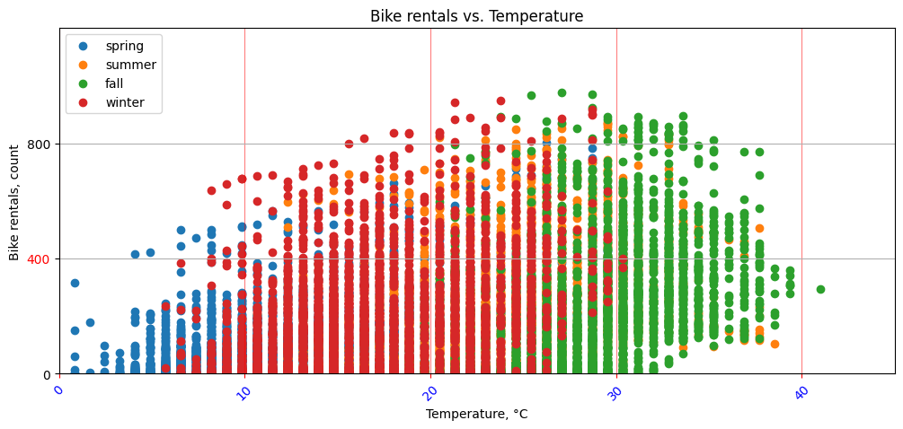

```python
make_plot()
plt.show()
```

A **catalogue cell** - every commented line changes one thing: figure size, title, labels, axis limits, where the ticks are, how the tick labels look (rotation, colour), the legend position, the grid.

## Seaborn

Seaborn is a data visualization library **based on matplotlib** that provides a high-level interface for drawing attractive and informative statistical graphics.

Key advantages:

1. Attractive and easily manageable themes
2. Usable statistical plots

seaborn's idea:

- you name the **DataFrame** and the **columns** (`data=`, `x=`, `y=`), and say which column should become **colour** (`hue=`) or **panels** (`col=`, `row=`) - seaborn does the grouping, the loop over colours and the legend that we wrote by hand with matplotlib above.
- It is installed in Colab (`import seaborn as sns`; `sns` is the conventional name).

```python
import seaborn as sns
```

## Themes: Accent palette

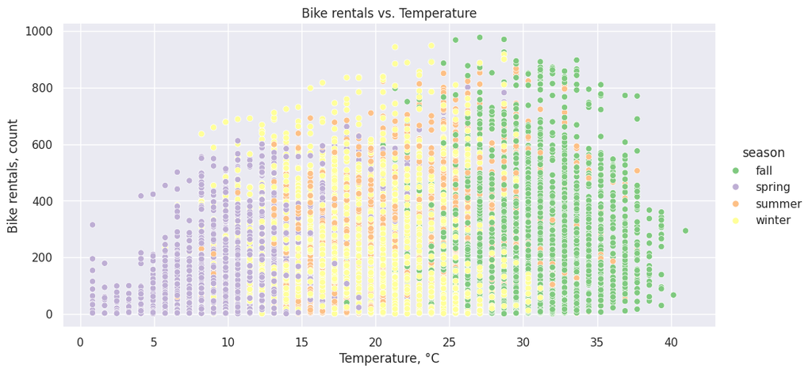

```python
sns.set(rc={'figure.dpi':100, 'figure.figsize':(6,4)})
sns.set(style="darkgrid", palette="Accent")
ax = sns.relplot(data = bikes, x='temp', y='count', kind="scatter", hue="season", aspect=2)
ax.set(xlabel = "Temperature, "+deg+"C", ylabel = 'Bike rentals, count', title="Bike rentals vs. Temperature");
```

## Themes: Colorblind palette

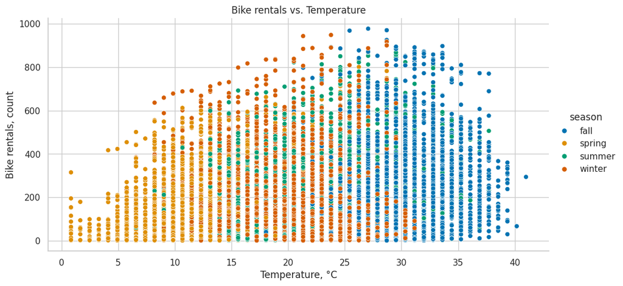

```python
sns.set(style="whitegrid", palette="colorblind")
ax = sns.relplot(data = bikes, x='temp', y='count', kind="scatter", hue="season", aspect=2)
ax.set(xlabel = "Temperature, "+deg+"C", ylabel = 'Bike rentals, count', title="Bike rentals vs. Temperature");
```

About 8 % of men cannot tell red from green. The `colorblind` palette is readable for everyone and is a sensible default for anything you publish - principle 1, *focus on your audience*. `whitegrid` is the usual theme for printed reports.

## Advanced plots: Histogram + Density

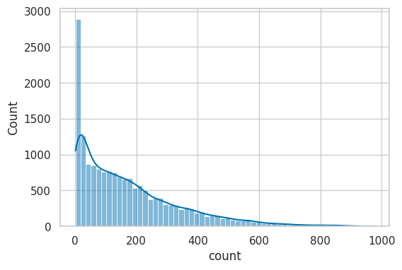

```python
sns.histplot(data=bikes, x='count', kde=True);
```

Histogram and density curve in one call (`kde=True` - kernel density estimate; the counts are the truth, the curve is the smoothed guide). `histplot` is *axes-level* - it returns a matplotlib Axes, so `set_title` / `set_xlabel` work directly on it. Add `hue="season"` to get one coloured histogram per season.